# SDG under-five mortality status and birth health services

[figure not shown]

##### Under 5 mortality and health services

- The SDG 3.2 aims to end preventable deaths of newborns and children under 5 years of age by 2030. The United Nations Inter-agency group for Child Mortality Estimation (UN IGME) provides a classification that indicates countries that are on-track or off-track to achieve this target.
- Were identified 141 countries/areas on-track and 59 countries/areas off-track to achieve this goal. Scientific literature suggests that [antenatal care](https://www.ncbi.nlm.nih.gov/pmc/articles/PMC6743758/) and [skilled birth attendant](https://link.springer.com/article/10.1007/s10995-013-1260-7) could be strategic health services to prevent under-five mortality.
- **Data indicates that countries off-track also have a lower population-weighted coverage of births with antenatal care and skilled birth attendant.** This data combined with literature reviews may suggest that actions to strengthen these health services could enhance the achievement of SDG 3.2.

##### Caveats

- Despite the hypothesis, data itself does not allow casual inference. For example, studies also indicates a complex [relation between antenatal care/ skilled birth attendant](https://www.ncbi.nlm.nih.gov/pmc/articles/PMC9778501/) and [differential effects depending on region](https://link.springer.com/article/10.1007/s10995-013-1260-7).
- Data used for analysis: The on/off track classification was based on data provided by UN IGME. To estimate population-weighted coverage were used data on projected births for 2022 for each country by UN World Population Prospects linked with most recent UNICEF Global Data for health services (2018 to 2022). One important limitation is that antenatal care data was available for 81 countries and skilled birth data was available for 135 countries.

### Estimated population-weighted coverage of births with antenatal care and skilled birth attendant for countries on-track/off-track for SDG under-five mortality

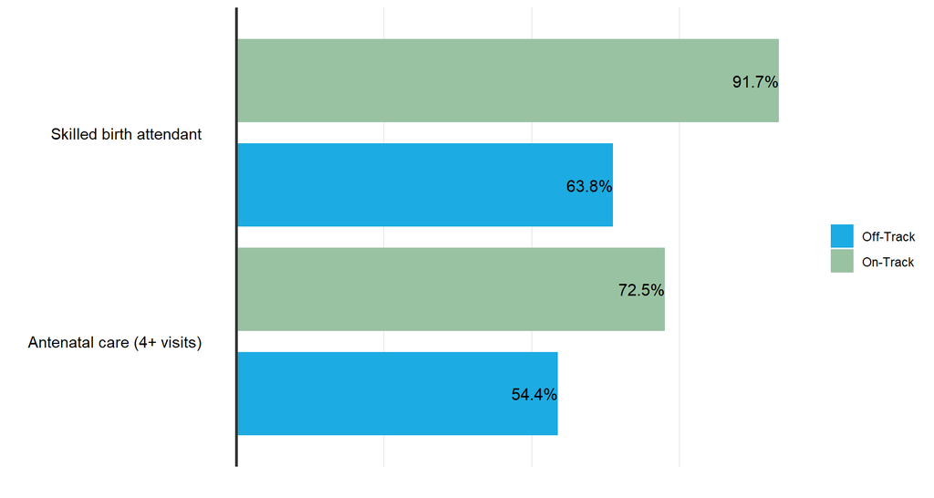